# GUI 13 17 descriptive

Oscar Cassetti

5/11/2021

```r
knitr::opts_chunk$set(echo = FALSE, warning = FALSE, tidy = TRUE)

conf <- load_config("../../configs/gui_data.yaml")
```

# 1 Data conversion

We convert the data from SPPS to R using our `convertGUI` package.

```r
xguiDF9 <- convertGUI(conf$data_repositories$gui_9_yo, "9-yo-cols.csv", version = 2)
xguiDF13 <- convertGUI(conf$data_repositories$gui_13_yo, "13-yo-cols.csv", version = 2)
xguiDF17 <- convertGUI(conf$data_repositories$gui_17_yo, "17-yo-cols.csv", version = 2)
```

In wave 1 BMI was not computed directly, computation done here:

## 1.1 IOTF and BMI calculation for 9 years old (wave 1)

# 2 Survey Overiew

Total count by wave

| wave | total |
| --- | --- |
| wave_1 | 8568 |
| wave_2 | 7525 |
| wave_3 | 6216 |

Split by gender

| Gender_yp | n | prop | wave |
| --- | --- | --- | --- |
| male | 4164 | 0.49 | wave_1 |
| female | 4404 | 0.51 | wave_1 |
| male | 3682 | 0.49 | wave_2 |
| female | 3843 | 0.51 | wave_2 |
| male | 3033 | 0.49 | wave_3 |
| female | 3183 | 0.51 | wave_3 |

| wave | total | diff | prop_diff |
| --- | --- | --- | --- |
| wave_1 | 8568 | NA | NA |
| wave_2 | 7525 | 1043 | 0.1217320 |
| wave_3 | 6216 | 1309 | 0.1739535 |

| Gender_yp | diff | prop_diff | prop |
| --- | --- | --- | --- |
| male | 482 | 0.1157541 | 0.2049320 |
| male | 649 | 0.1762629 | 0.2759354 |
| female | 561 | 0.1273842 | 0.2385204 |
| female | 660 | 0.1717408 | 0.2806122 |

# 3 Weighted

Total count by wave

| wave | total |
| --- | --- |
| wave_1 | 8567.942 |
| wave_2 | 7524.959 |
| wave_3 | 6215.990 |

Split by gender

| Gender_yp | n | prop | wave |
| --- | --- | --- | --- |
| male | 4381.189 | 0.51 | wave_1 |
| female | 4186.753 | 0.49 | wave_1 |
| male | 3833.317 | 0.51 | wave_2 |
| female | 3691.641 | 0.49 | wave_2 |
| male | 3182.534 | 0.51 | wave_3 |
| female | 3033.455 | 0.49 | wave_3 |

Drop off

| wave | total | diff | prop_diff |
| --- | --- | --- | --- |
| wave_1 | 8567.942 | NA | NA |
| wave_2 | 7524.959 | 1042.983 | 0.1217309 |
| wave_3 | 6215.990 | 1308.969 | 0.1739503 |

Drop off by gender

| Gender_yp | diff | prop_diff | prop |
| --- | --- | --- | --- |
| male | 547.8713 | 0.1250508 | 0.2329432 |
| male | 650.7831 | 0.1697702 | 0.2766991 |
| female | 495.1116 | 0.1182567 | 0.2105109 |
| female | 658.1860 | 0.1782909 | 0.2798467 |

## 3.1 Descriptive longitudinal

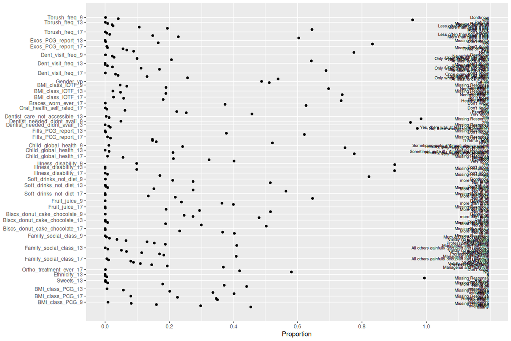

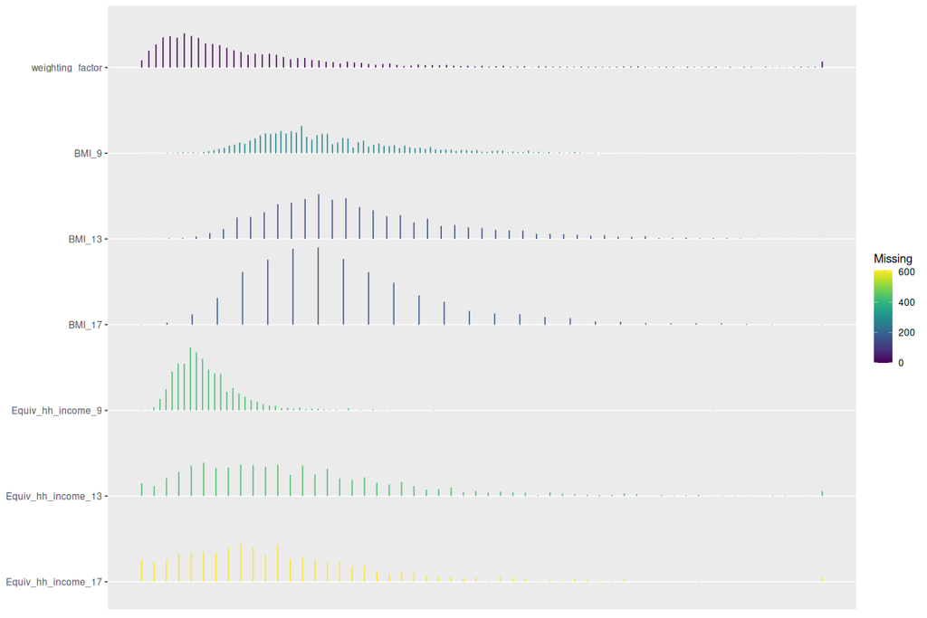

### 3.1.1 Summaries

.  
49 Variables 6039 Observations

Tbrush_freq_9: C8. Study Child brush teeth at least once daily

| n | missing | distinct |
| --- | --- | --- |
| 6039 | 0 | 3 |

```
 Value           yes       no Dontknow
 Frequency      5782      248        9
 Proportion    0.957    0.041    0.001
```

Tbrush_freq_13: Q34. How often do you brush your teeth?

| n | missing | distinct |
| --- | --- | --- |
| 6039 | 0 | 7 |

| lowest : | More than twice a day | Twice a day | Once a day | Less often than once a day | Rarely / Not at all |
| --- | --- | --- | --- | --- | --- |
| highest: | Once a day | Less often than once a day | Rarely / Not at all | Refusal | Missing Response |

More than twice a day (641, 0.106), Twice a day (3893, 0.645), Once a day (1170, 0.194), Less often than once a day (149, 0.025), Rarely / Not at all (132, 0.022), Refusal (5, 0.001), Missing Response (49, 0.008)

Tbrush_freq_17: O2. How often do you brush your teeth

| n | missing | distinct |
| --- | --- | --- |
| 6039 | 0 | 6 |

| lowest : | More than twice a day | Twice a day | Once a day | Less often than once a day | Rarely |
| --- | --- | --- | --- | --- | --- |
| highest: | Twice a day | Once a day | Less often than once a day | Rarely | Don't Know |

```
 Value           More than twice a day                Twice a day
 Frequency                        1375                       3645
 Proportion                      0.228                      0.604

 Value                      Once a day Less often than once a day
 Frequency                         894                         87
 Proportion                      0.148                      0.014

 Value                          Rarely                 Don't Know
 Frequency                          33                          5
 Proportion                      0.005                      0.001
```

Exos_PCG_report_13: B20. Has child ever had?: (b) Any permanent/secondary teeth pulled?

| n | missing | distinct |
| --- | --- | --- |
| 6039 | 0 | 4 |

```
 Value                   yes               no       Don't Know Missing Response
 Frequency               998             5029               11                1
 Proportion            0.165            0.833            0.002            0.000
```

Exos_PCG_report_17: B9. How many permanent teeth YP has had extracted

| n | missing | distinct |
| --- | --- | --- |
| 6039 | 0 | 6 |

| lowest : | None | One | Two | Three or more | Don't Know |
| --- | --- | --- | --- | --- | --- |
| highest: | One | Two | Three or more | Don't Know | Missing Response |

```
 Value                  None              One              Two    Three or more
 Frequency              4680              536              408              337
 Proportion            0.775            0.089            0.068            0.056

 Value            Don't Know Missing Response
 Frequency                32               46
 Proportion            0.005            0.008
```

Dent_visit_freq_9: C9. Study Childs frequency of dental visits

| n | missing | distinct |
| --- | --- | --- |
| 6039 | 0 | 6 |

| lowest : | At least once a year | Once every two years | Once every three years | Only when there is a problem | Never/almost never |
| --- | --- | --- | --- | --- | --- |
| highest: | Once every two years | Once every three years | Only when there is a problem | Never/almost never | Dontknow |

At least once a year (3881, 0.643), Once every two years (1246, 0.206), Once every three years (170, 0.028), Only when there is a problem (600, 0.099), Never/almost never (134, 0.022), Dontknow (8, 0.001)

Dent_visit_freq_13: B19. Which of the following best describes how regularly child visits the dentist?

| n | missing | distinct |
| --- | --- | --- |
| 6039 | 0 | 7 |

| lowest : | At least once a year | Once every two years | Once every three years | Only when there is a problem | Never/almost never |
| --- | --- | --- | --- | --- | --- |
| highest: | Once every three years | Only when there is a problem | Never/almost never | Don't Know | Missing Response |

At least once a year (4157, 0.688), Once every two years (1021, 0.169), Once every three years (139, 0.023), Only when there is a problem (675, 0.112), Never/almost never (45, 0.007), Don't Know (1, 0.000), Missing Response (1, 0.000)

Dent_visit_freq_17: O3. How often visits the dentist

| n | missing | distinct |
| --- | --- | --- |
| 6039 | 0 | 6 |

| lowest : | At least once a year | Once every two years | Once every three years | Only when there is a problem | Never/almost never |
| --- | --- | --- | --- | --- | --- |
| highest: | Once every two years | Once every three years | Only when there is a problem | Never/almost never | Don't Know |

At least once a year (3257, 0.539), Once every two years (788, 0.130), Once every three years (196, 0.032), Only when there is a problem (1548, 0.256), Never/almost never (244, 0.040), Don't Know (6, 0.001)

weighting_factor: Weighting Factor - 17yr – Full sample (9yr & 17yr) Format:F8.2

| n | missing | distinct | Info | Mean | Gmd | .05 | .10 | .25 | .50 | .75 | .90 | .95 |
| --- | --- | --- | --- | --- | --- | --- | --- | --- | --- | --- | --- | --- |
| 6039 | 0 | 5978 | 1 | 0.9969 | 0.8432 | 0.2364 | 0.2917 | 0.4342 | 0.6978 | 1.2030 | 2.0532 | 2.9451 |

| lowest : | 0.1271185 | 0.1340005 | 0.1342876 | 0.1354338 | 0.1363615 |
| --- | --- | --- | --- | --- | --- |
| highest: | 4.9023850 | 4.9122514 | 4.9126212 | 4.9287097 | 4.9413613 |

Gender_yp: Gender P2

| n | missing | distinct |
| --- | --- | --- |
| 6039 | 0 | 2 |

```
 Value        male female
 Frequency    2947   3092
 Proportion  0.488  0.512
```

BMI_class_IOTF_9

| n | missing | distinct |
| --- | --- | --- |
| 6039 | 0 | 4 |

```
 Value      Missing Response   Non-overweight       Overweight            Obese
 Frequency               282             4205             1144              408
 Proportion            0.047            0.696            0.189            0.068
```

BMI_9

| n | missing | distinct | Info | Mean | Gmd | .05 | .10 | .25 | .50 | .75 | .90 | .95 |
| --- | --- | --- | --- | --- | --- | --- | --- | --- | --- | --- | --- | --- |
| 5757 | 282 | 731 | 1 | 17.76 | 3.15 | 14.11 | 14.70 | 15.75 | 17.10 | 19.23 | 21.82 | 23.59 |

lowest : 10.60957 10.71429 10.93936 11.18866 11.38657 , highest: 29.56195 29.93069 31.74426 36.28057 37.07076

BMI_13: Child's BMI - derived from measured data Format:F8.2

| n | missing | distinct | Info | Mean | Gmd | .05 | .10 | .25 | .50 | .75 | .90 | .95 |
| --- | --- | --- | --- | --- | --- | --- | --- | --- | --- | --- | --- | --- |
| 5892 | 147 | 50 | 0.997 | 20.58 | 3.913 | 16.0 | 16.5 | 18.0 | 20.0 | 22.5 | 25.5 | 28.0 |

lowest : 12.5 13.0 13.5 14.0 14.5 , highest: 35.0 35.5 36.0 36.5 37.5

BMI_class_IOTF_13: Study Childs IOTF BMI classification at 13 - derived from measured data

| n | missing | distinct |
| --- | --- | --- |
| 6039 | 0 | 4 |

```
 Value        Non-overweight       Overweight            Obese Missing Response
 Frequency              4461             1141              290              147
 Proportion            0.739            0.189            0.048            0.024
```

BMI_17: Young Person's BMI at age 17/18 Format:F8.2

| n | missing | distinct | Info | Mean | Gmd | .05 | .10 | .25 | .50 | .75 | .90 | .95 |
| --- | --- | --- | --- | --- | --- | --- | --- | --- | --- | --- | --- | --- |
| 5880 | 159 | 27 | 0.991 | 22.93 | 3.996 | 18 | 19 | 20 | 22 | 25 | 28 | 30 |

lowest : 15 16 17 18 19 , highest: 37 38 39 40 42

BMI_class_IOTF_17: Young Person's BMI status at Wave 3

| n | missing | distinct |
| --- | --- | --- |
| 6039 | 0 | 4 |

```
 Value      Healthy weight     Overweight          Obese     don't know
 Frequency            4441           1091            348            159
 Proportion          0.735          0.181          0.058          0.026
```

Braces_worn_ever_17: O5. Ever worn braces

| n | missing | distinct |
| --- | --- | --- |
| 6039 | 0 | 3 |

```
 Value             Yes         No Don't Know
 Frequency        2252       3782          5
 Proportion      0.373      0.626      0.001
```

Oral_health_self_rated_17: O1. How would you rate your oral health

| n | missing | distinct |
| --- | --- | --- |
| 6039 | 0 | 6 |

| lowest : | Excellent | Very good | Good | Fair | Poor |
| --- | --- | --- | --- | --- | --- |
| highest: | Very good | Good | Fair | Poor | Don't Know |

```
 Value       Excellent  Very good       Good       Fair       Poor Don't Know
 Frequency        1345       2757       1524        373         35          5
 Proportion      0.223      0.457      0.252      0.062      0.006      0.001
```

Dentist_care_not_accessible_13: B22b. Main reason - The necessary medical care wasn’t available or accessible to you

| n | missing | distinct |
| --- | --- | --- |
| 6039 | 0 | 3 |

```
 Value                   yes               no Missing Response
 Frequency                22               76             5941
 Proportion            0.004            0.013            0.984
```

Dentist_needed_didnt_avail_9: C6. Last 12mths, didnt receive dental care that was needed

| n | missing | distinct |
| --- | --- | --- |
| 6039 | 0 | 2 |

```
 Value        yes    no
 Frequency    297  5742
 Proportion 0.049 0.951
```

Dentist_needed_didnt_avail_13: B21. Was there any time during the past 12 months when child really needed to consult a dentist but did not?

| n | missing | distinct |
| --- | --- | --- |
| 6039 | 0 | 4 |

```
 Value      Yes, there was at least one occasion       No, there was no such occasion
 Frequency                                    98                                 5871
 Proportion                                0.016                                0.972

 Value                                Don't Know                     Missing Response
 Frequency                                    69                                    1
 Proportion                                0.011                                0.000
```

Fills_PCG_report_13: B20. Has child ever had?: (a) Any permanent/secondary teeth filled?

| n | missing | distinct |
| --- | --- | --- |
| 6039 | 0 | 4 |

```
 Value                   yes               no       Don't Know Missing Response
 Frequency              2277             3751               10                1
 Proportion            0.377            0.621            0.002            0.000
```

Fills_PCG_report_17: B8. How many permanent teeth YP has had filled

| n | missing | distinct |
| --- | --- | --- |
| 6039 | 0 | 6 |

| lowest : | None | One | Two | Three or more | Don't Know |
| --- | --- | --- | --- | --- | --- |
| highest: | One | Two | Three or more | Don't Know | Missing Response |

```
 Value                  None              One              Two    Three or more
 Frequency              3151              889              961              891
 Proportion            0.522            0.147            0.159            0.148

 Value            Don't Know Missing Response
 Frequency               101               46
 Proportion            0.017            0.008
```

Child_global_health_9: B10. Study Childs health past year

| n | missing | distinct |
| --- | --- | --- |
| 6039 | 0 | 3 |

```
 Value                     Very healthy, no problems
 Frequency                                      4513
 Proportion                                    0.747

 Value             Healthy, but a few minor problems
 Frequency                                      1455
 Proportion                                    0.241

 Value      Sometimes quite ill/Almost always unwell
 Frequency                                        71
 Proportion                                    0.012
```

Child_global_health_13: B1. In general, how would you describe childs health in the past year?

| n | missing | distinct |
| --- | --- | --- |
| 6039 | 0 | 4 |

Very healthy, no problems (4687, 0.776), Healthy, but a few minor problems (1275, 0.211), Sometimes quite ill / Almost always unwell (76, 0.013), Missing Response (1, 0.000)

Child_global_health_17: A1. How would you say your current health is in general

| n | missing | distinct |
| --- | --- | --- |
| 6039 | 0 | 5 |

| lowest : | Excellent | Very good | Good | Not good | Missing Response |
| --- | --- | --- | --- | --- | --- |
| highest: | Excellent | Very good | Good | Not good | Missing Response |

```
 Value             Excellent        Very good             Good         Not good
 Frequency              1952             2421             1283              337
 Proportion            0.323            0.401            0.212            0.056

 Value      Missing Response
 Frequency                46
 Proportion            0.008
```

Illness_disability_9: B11. On-going chronic illness etc.

| n | missing | distinct |
| --- | --- | --- |
| 6039 | 0 | 2 |

```
 Value        yes    no
 Frequency    593  5446
 Proportion 0.098 0.902
```

Illness_disability_13: B2. Does child have any on-going chronic physical or mental health problem, illness or disability?

| n | missing | distinct |
| --- | --- | --- |
| 6039 | 0 | 4 |

```
 Value                   yes               no       Don't Know Missing Response
 Frequency               594             5443                1                1
 Proportion            0.098            0.901            0.000            0.000
```

Illness_disability_17: A2. Have you any on-going chronic physical or mental health problem, illness or disability

| n | missing | distinct |
| --- | --- | --- |
| 6039 | 0 | 4 |

```
 Value                   Yes               No       Don't Know Missing Response
 Frequency              1029             4963                1               46
 Proportion            0.170            0.822            0.000            0.008
```

Soft_drinks_not_diet_9: D1q. Soft drinks / minerals / cordial / squash (not diet)

| n | missing | distinct |
| --- | --- | --- |
| 6039 | 0 | 4 |

```
 Value                once more than once     Not at all       Dontknow
 Frequency            1652           1269           3111              7
 Proportion          0.274          0.210          0.515          0.001
```

Soft_drinks_not_diet_13: Q33M. Fizzy drinks / minerals / cordial / squash (not diet)

| n | missing | distinct |
| --- | --- | --- |
| 6039 | 0 | 6 |

| lowest : | Once | More than once | Not at all | Refusal | Don't Know |
| --- | --- | --- | --- | --- | --- |
| highest: | More than once | Not at all | Refusal | Don't Know | Missing Response |

```
 Value                  Once   More than once       Not at all          Refusal
 Frequency              1652              916             3405                5
 Proportion            0.274            0.152            0.564            0.001

 Value            Don't Know Missing Response
 Frequency                12               49
 Proportion            0.002            0.008
```

Soft_drinks_not_diet_17: N1q. How often had in the last 24hrs - Soft drinks / minerals / cordial / squash (not diet)

| n | missing | distinct |
| --- | --- | --- |
| 6039 | 0 | 5 |

| lowest : | Once | More than once | Not at all | Don't Know | Missing Response |
| --- | --- | --- | --- | --- | --- |
| highest: | Once | More than once | Not at all | Don't Know | Missing Response |

```
 Value                  Once   More than once       Not at all       Don't Know
 Frequency              1318              811             3904                5
 Proportion            0.218            0.134            0.646            0.001

 Value      Missing Response
 Frequency                 1
 Proportion            0.000
```

Fruit_juice_9: D1b. Fruit juice

| n | missing | distinct |
| --- | --- | --- |
| 6039 | 0 | 4 |

```
 Value                once more than once     Not at all       Dontknow
 Frequency            2409           2194           1434              2
 Proportion          0.399          0.363          0.237          0.000
```

Fruit_juice_17: N1b. How often had in the last 24hrs - Fruit juice

| n | missing | distinct |
| --- | --- | --- |
| 6039 | 0 | 5 |

| lowest : | Once | More than once | Not at all | Don't Know | Missing Response |
| --- | --- | --- | --- | --- | --- |
| highest: | Once | More than once | Not at all | Don't Know | Missing Response |

```
 Value                  Once   More than once       Not at all       Don't Know
 Frequency              1773             1146             3114                5
 Proportion            0.294            0.190            0.516            0.001

 Value      Missing Response
 Frequency                 1
 Proportion            0.000
```

Biscs_donut_cake_chocolate_9: D1m. Biscuits, doughnuts, cake, pie or chocolate

| n | missing | distinct |
| --- | --- | --- |
| 6039 | 0 | 4 |

```
 Value                once more than once     Not at all       Dontknow
 Frequency            2900           1651           1484              4
 Proportion          0.480          0.273          0.246          0.001
```

Biscs_donut_cake_chocolate_13: Q33G. Biscuits, doughnuts, cake, pie or chocolate

| n | missing | distinct |
| --- | --- | --- |
| 6039 | 0 | 6 |

| lowest : | Once | More than once | Not at all | Refusal | Don't Know |
| --- | --- | --- | --- | --- | --- |
| highest: | More than once | Not at all | Refusal | Don't Know | Missing Response |

```
 Value                  Once   More than once       Not at all          Refusal
 Frequency              3035             1136             1807                5
 Proportion            0.503            0.188            0.299            0.001

 Value            Don't Know Missing Response
 Frequency                 7               49
 Proportion            0.001            0.008
```

Biscs_donut_cake_chocolate_17: N1m. How often had in the last 24hrs - Biscuits, doughnuts, cake, pie or chocolate

| n | missing | distinct |
| --- | --- | --- |
| 6039 | 0 | 5 |

| lowest : | Once | More than once | Not at all | Don't Know | Missing Response |
| --- | --- | --- | --- | --- | --- |
| highest: | Once | More than once | Not at all | Don't Know | Missing Response |

```
 Value                  Once   More than once       Not at all       Don't Know
 Frequency              2427             1400             2206                5
 Proportion            0.402            0.232            0.365            0.001

 Value      Missing Response
 Frequency                 1
 Proportion            0.000
```

Family_social_class_9: hsd class

| n | missing | distinct |
| --- | --- | --- |
| 6039 | 0 | 9 |

| lowest : | Professional Managers | Managerial and Technical | Non-manual | Skilled manual | Semi-skilled |
| --- | --- | --- | --- | --- | --- |
| highest: | Semi-skilled | Unskilled | Validly no social class | Mum & Dad not resident | Missing Response |

Family_social_class_13: Family's social class - Wave 2

| n | missing | distinct |
| --- | --- | --- |
| 6039 | 0 | 8 |

| lowest : | Professional workers | Managerial and technical | Non-manual | Skilled manual | Semi-skilled |
| --- | --- | --- | --- | --- | --- |
| highest: | Skilled manual | Semi-skilled | Unskilled | All others gainfully occupied and unknown | Validly no social class |

Family_social_class_17: Family's social class - Wave 3

| n | missing | distinct |
| --- | --- | --- |
| 6039 | 0 | 8 |

| lowest : | Professional workers | Managerial and technical | Non-manual | Skilled manual | Semi-skilled |
| --- | --- | --- | --- | --- | --- |
| highest: | Skilled manual | Semi-skilled | Unskilled | All others gainfully occupied and unknown | Validly no social class |

Equiv_hh_income_9: Equivalised Household Annual Income Format:F8.2

| n | missing | distinct | Info | Mean | Gmd | .05 | .10 | .25 | .50 | .75 | .90 | .95 |
| --- | --- | --- | --- | --- | --- | --- | --- | --- | --- | --- | --- | --- |
| 5613 | 426 | 1867 | 1 | 21924 | 12425 | 8372 | 10345 | 13960 | 19138 | 25862 | 34912 | 42178 |

| lowest : | 503.7783 | 503.7783 | 671.1409 | 1204.8193 | 2268.4310 |
| --- | --- | --- | --- | --- | --- |
| highest: | 172413.7931 | 181034.4828 | 188679.2453 | 215517.2414 | 223115.5779 |

Equiv_hh_income_13

| n | missing | distinct | Info | Mean | Gmd | .05 | .10 | .25 | .50 | .75 | .90 | .95 |
| --- | --- | --- | --- | --- | --- | --- | --- | --- | --- | --- | --- | --- |
| 5610 | 429 | 54 | 0.998 | 17986 | 10014 | 7000 | 8000 | 11000 | 16000 | 22000 | 30000 | 36000 |

lowest : 5000 6000 7000 8000 9000 , highest: 56000 57000 58000 59000 60000

Equiv_hh_income_17

| n | missing | distinct | Info | Mean | Gmd | .05 | .10 | .25 | .50 | .75 | .90 | .95 |
| --- | --- | --- | --- | --- | --- | --- | --- | --- | --- | --- | --- | --- |
| 5429 | 610 | 52 | 0.998 | 16604 | 9409 | 6000 | 7000 | 10000 | 15000 | 20000 | 27000 | 34000 |

lowest : 5000 6000 7000 8000 9000 , highest: 54000 55000 56000 57000 60000

Ortho_treatment_ever_17: O4. Ever had orthodontic treatment

| n | missing | distinct |
| --- | --- | --- |
| 6039 | 0 | 3 |

```
 Value             Yes         No Don't Know
 Frequency        2525       3507          7
 Proportion      0.418      0.581      0.001
```

Ethnicity_13: Q45A. Ethnicity / race / nationality / skin colour

| n | missing | distinct |
| --- | --- | --- |
| 6039 | 0 | 4 |

```
 Value                     1                8                9 Missing Response
 Frequency                32                1                2             6004
 Proportion            0.005            0.000            0.000            0.994
```

Sweets_13: Q33H. Sweets

| n | missing | distinct |
| --- | --- | --- |
| 6039 | 0 | 6 |

| lowest : | Once | More than once | Not at all | Refusal | Don't Know |
| --- | --- | --- | --- | --- | --- |
| highest: | More than once | Not at all | Refusal | Don't Know | Missing Response |

```
 Value                  Once   More than once       Not at all          Refusal
 Frequency              2657             1082             2236                6
 Proportion            0.440            0.179            0.370            0.001

 Value            Don't Know Missing Response
 Frequency                 9               49
 Proportion            0.001            0.008
```

BMI_class_PCG_13: Primary Caregiver's BMI classification- derived from measured data

| n | missing | distinct |
| --- | --- | --- |
| 6039 | 0 | 5 |

| lowest : | underweight | healthy | overweight | obese | Missing Response |
| --- | --- | --- | --- | --- | --- |
| highest: | underweight | healthy | overweight | obese | Missing Response |

```
 Value           underweight          healthy       overweight            obese
 Frequency                37             2422             2024             1213
 Proportion            0.006            0.401            0.335            0.201

 Value      Missing Response
 Frequency               343
 Proportion            0.057
```

BMI_class_PCG_17: Primary Caregiver's BMI classification- derived from measured data

| n | missing | distinct |
| --- | --- | --- |
| 6039 | 0 | 4 |

```
 Value        Healthy weight       Overweight            Obese Missing Response
 Frequency              2086             2110             1359              484
 Proportion            0.345            0.349            0.225            0.080
```

BMI_class_PCG_9: Primary Caregiver's BMI classification- derived from measured data

| n | missing | distinct |
| --- | --- | --- |
| 6039 | 0 | 5 |

| lowest : | underweight | healthy | overweight | obese | Missing Response |
| --- | --- | --- | --- | --- | --- |
| highest: | underweight | healthy | overweight | obese | Missing Response |

```
 Value           underweight          healthy       overweight            obese
 Frequency                55             2735             1794              964
 Proportion            0.009            0.453            0.297            0.160

 Value      Missing Response
 Frequency               491
 Proportion            0.081
```

# 4 Before remapping

[output not shown]

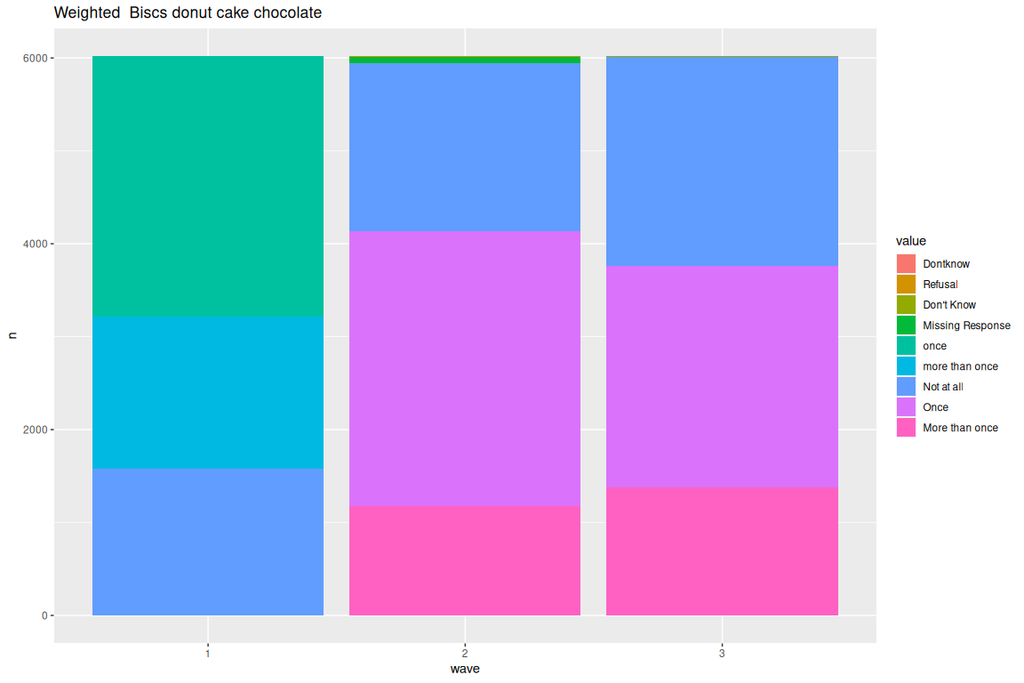

|  | 1 | 2 | 3 |
| --- | --- | --- | --- |
| Don’t Know | 0 | 5 | 6 |
| Dontknow | 2 | 0 | 0 |
| Missing Response | 0 | 67 | 0 |
| more than once | 1638 | 0 | 0 |
| More than once | 0 | 1174 | 1380 |
| Not at all | 1576 | 1807 | 2253 |
| once | 2804 | 0 | 0 |
| Once | 0 | 2962 | 2380 |
| Refusal | 0 | 4 | 0 |

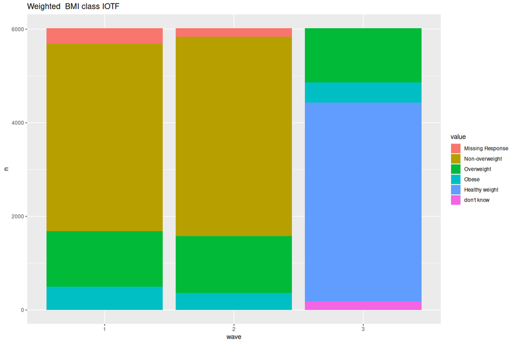

|  | 1 | 2 | 3 |
| --- | --- | --- | --- |
| don’t know | 0 | 0 | 182 |
| Healthy weight | 0 | 0 | 4251 |
| Missing Response | 330 | 180 | 0 |
| Non-overweight | 4005 | 4258 | 0 |
| Obese | 502 | 363 | 431 |
| Overweight | 1183 | 1219 | 1157 |

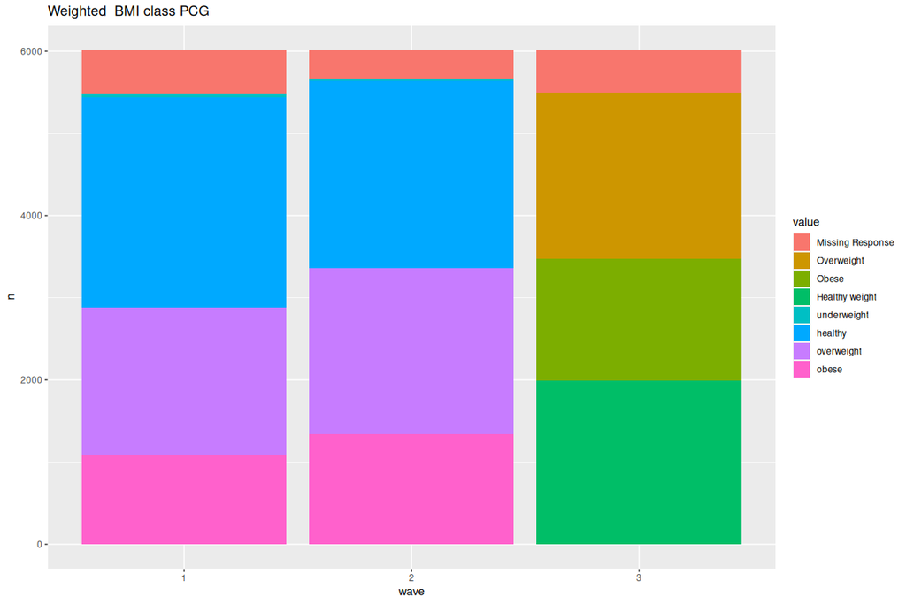

|  | 1 | 2 | 3 |
| --- | --- | --- | --- |
| healthy | 2553 | 2272 | 0 |
| Healthy weight | 0 | 0 | 1993 |
| Missing Response | 531 | 353 | 529 |
| obese | 1096 | 1340 | 0 |
| Obese | 0 | 0 | 1477 |
| overweight | 1787 | 2023 | 0 |
| Overweight | 0 | 0 | 2021 |
| underweight | 54 | 32 | 0 |

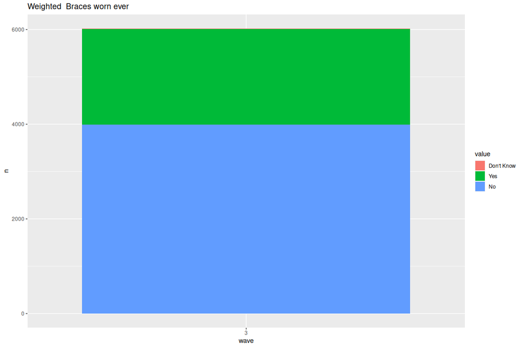

|  | 1 | 2 | 3 |
| --- | --- | --- | --- |
| Don’t Know | 0 | 0 | 6 |
| No | 0 | 0 | 3993 |
| Yes | 0 | 0 | 2021 |

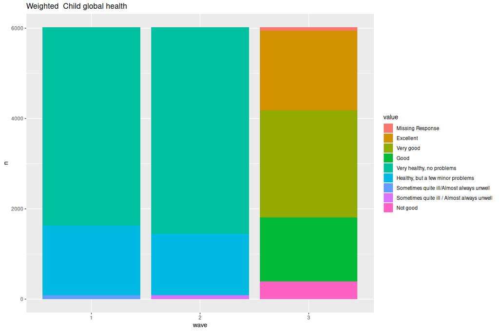

|  | 1 | 2 | 3 |
| --- | --- | --- | --- |
| Excellent | 0 | 0 | 1764 |
| Good | 0 | 0 | 1417 |
| Healthy, but a few minor problems | 1546 | 1361 | 0 |
| Missing Response | 0 | 1 | 74 |
| Not good | 0 | 0 | 394 |
| Sometimes quite ill / Almost always unwell | 0 | 84 | 0 |
| Sometimes quite ill/Almost always unwell | 85 | 0 | 0 |
| Very good | 0 | 0 | 2371 |
| Very healthy, no problems | 4389 | 4575 | 0 |

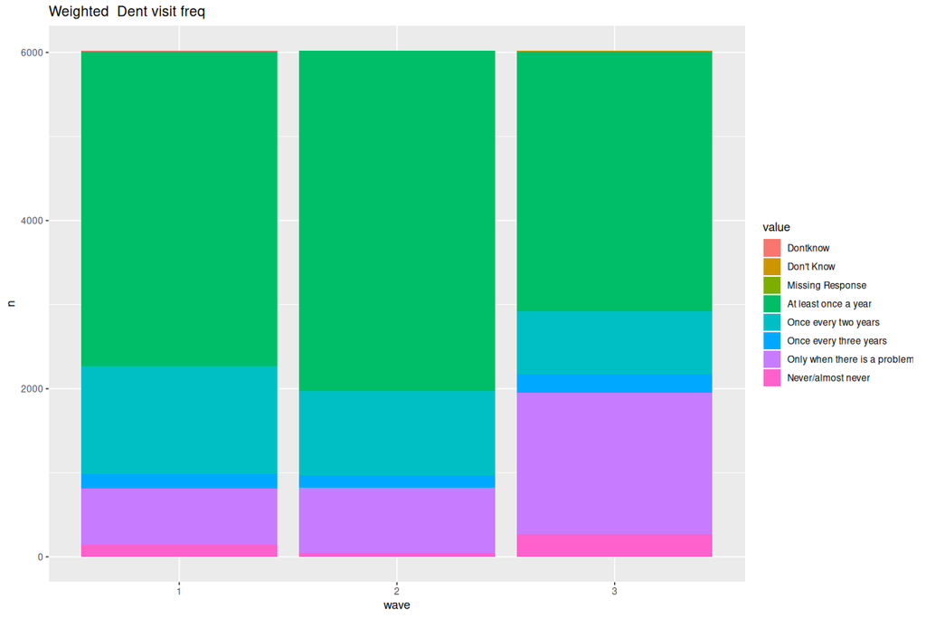

|  | 1 | 2 | 3 |
| --- | --- | --- | --- |
| At least once a year | 3747 | 4049 | 3092 |
| Don’t Know | 0 | 2 | 7 |
| Dontknow | 8 | 0 | 0 |
| Missing Response | 0 | 1 | 0 |
| Never/almost never | 144 | 53 | 270 |
| Once every three years | 167 | 140 | 215 |
| Once every two years | 1281 | 1002 | 749 |
| Only when there is a problem | 674 | 774 | 1687 |

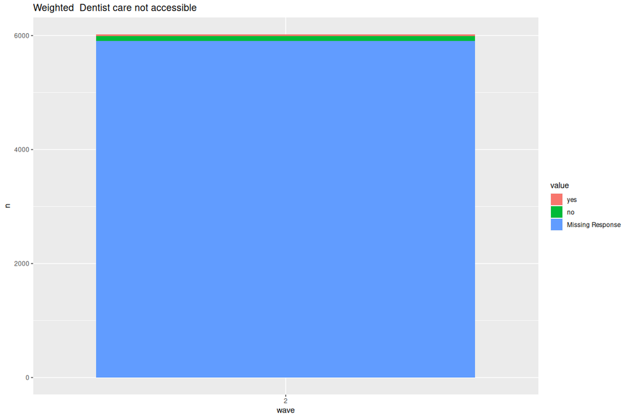

|  | 1 | 2 | 3 |
| --- | --- | --- | --- |
| Missing Response | 0 | 5910 | 0 |
| no | 0 | 84 | 0 |
| yes | 0 | 26 | 0 |

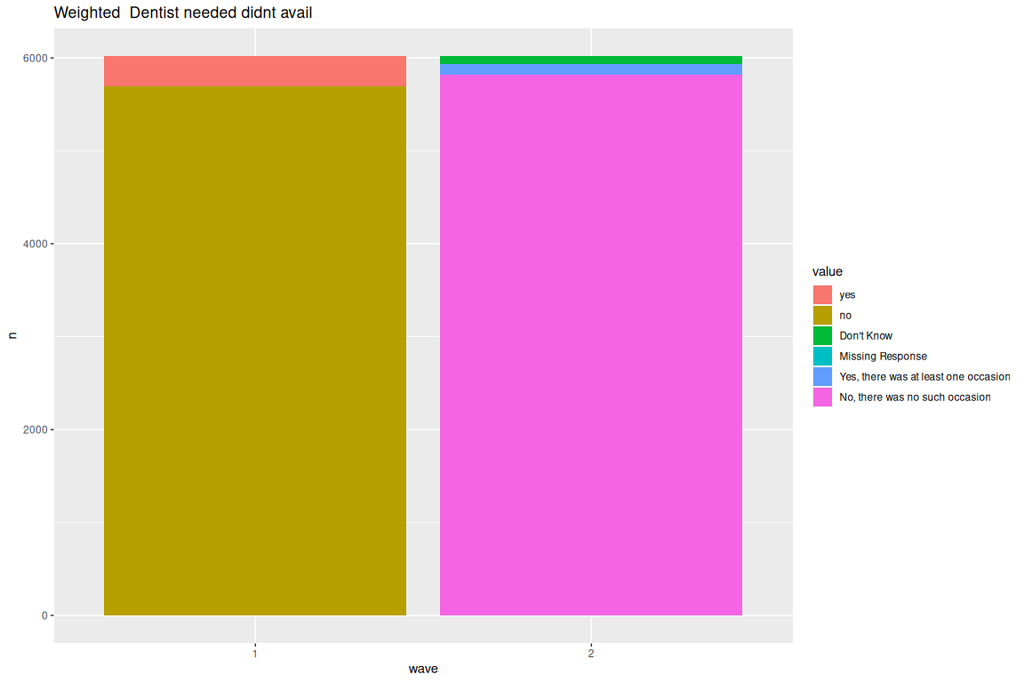

|  | 1 | 2 | 3 |
| --- | --- | --- | --- |
| Don’t Know | 0 | 87 | 0 |
| Missing Response | 0 | 1 | 0 |
| no | 5694 | 0 | 0 |
| No, there was no such occasion | 0 | 5823 | 0 |
| yes | 326 | 0 | 0 |
| Yes, there was at least one occasion | 0 | 110 | 0 |

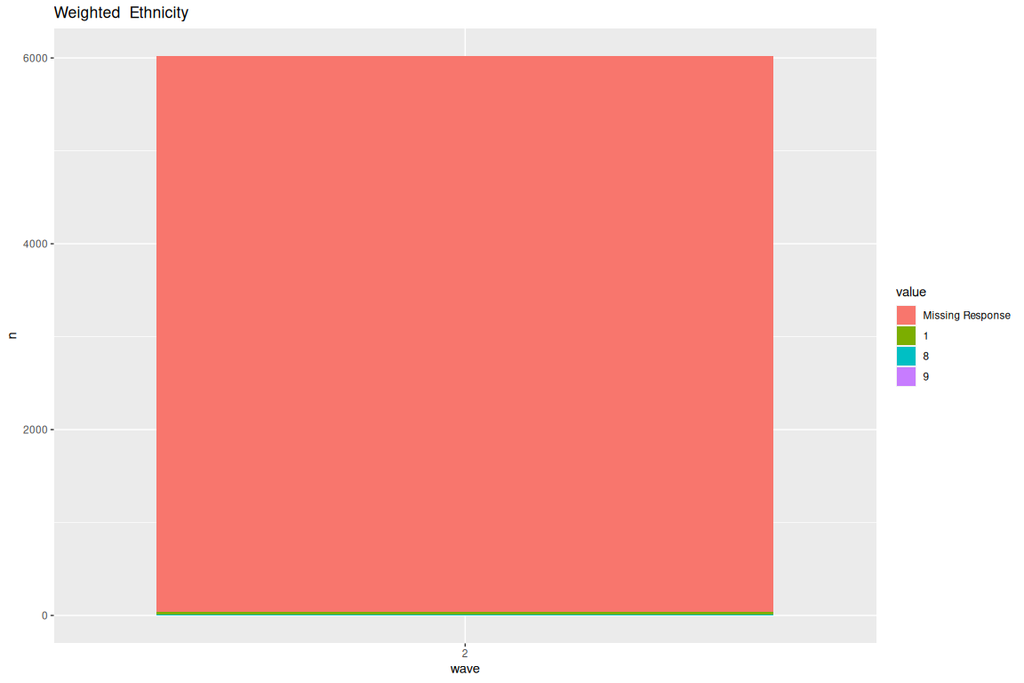

|  | 1 | 2 | 3 |
| --- | --- | --- | --- |
| 1 | 0 | 35 | 0 |
| 8 | 0 | 5 | 0 |
| 9 | 0 | 1 | 0 |
| Missing Response | 0 | 5979 | 0 |

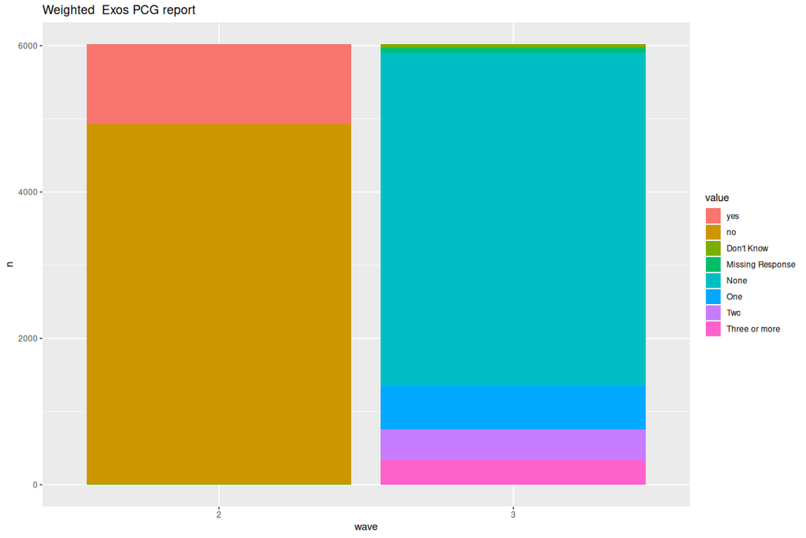

|  | 1 | 2 | 3 |
| --- | --- | --- | --- |
| Don’t Know | 0 | 12 | 43 |
| Missing Response | 0 | 1 | 74 |
| no | 0 | 4913 | 0 |
| None | 0 | 0 | 4559 |
| One | 0 | 0 | 585 |
| Three or more | 0 | 0 | 331 |
| Two | 0 | 0 | 429 |
| yes | 0 | 1094 | 0 |

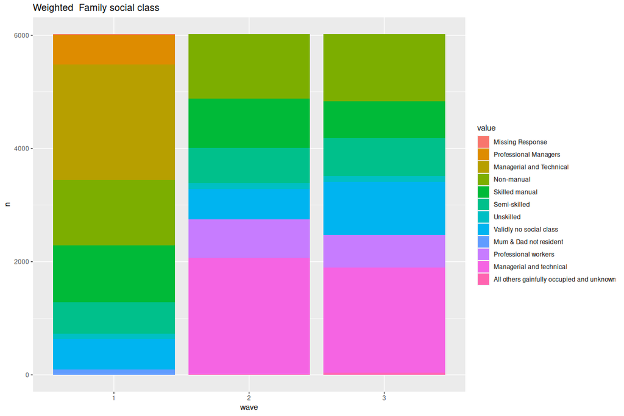

|  | 1 | 2 | 3 |
| --- | --- | --- | --- |
| All others gainfully occupied and unknown | 0 | 9 | 35 |
| Managerial and technical | 0 | 2055 | 1858 |
| Managerial and Technical | 2043 | 0 | 0 |
| Missing Response | 4 | 0 | 0 |
| Mum & Dad not resident | 94 | 0 | 0 |
| Non-manual | 1150 | 1135 | 1188 |
| Professional Managers | 531 | 0 | 0 |
| Professional workers | 0 | 679 | 578 |
| Semi-skilled | 552 | 624 | 671 |
| Skilled manual | 1009 | 877 | 648 |
| Unskilled | 103 | 99 | 111 |
| Validly no social class | 534 | 542 | 932 |

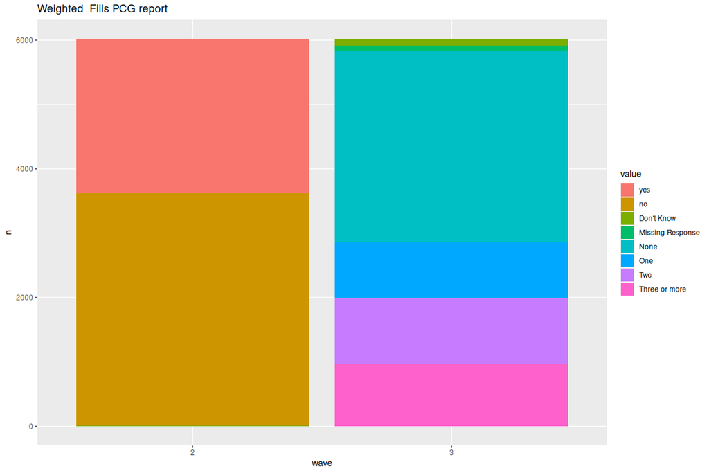

|  | 1 | 2 | 3 |
| --- | --- | --- | --- |
| Don’t Know | 0 | 11 | 106 |
| Missing Response | 0 | 1 | 74 |
| no | 0 | 3616 | 0 |
| None | 0 | 0 | 2974 |
| One | 0 | 0 | 879 |
| Three or more | 0 | 0 | 967 |
| Two | 0 | 0 | 1020 |
| yes | 0 | 2393 | 0 |

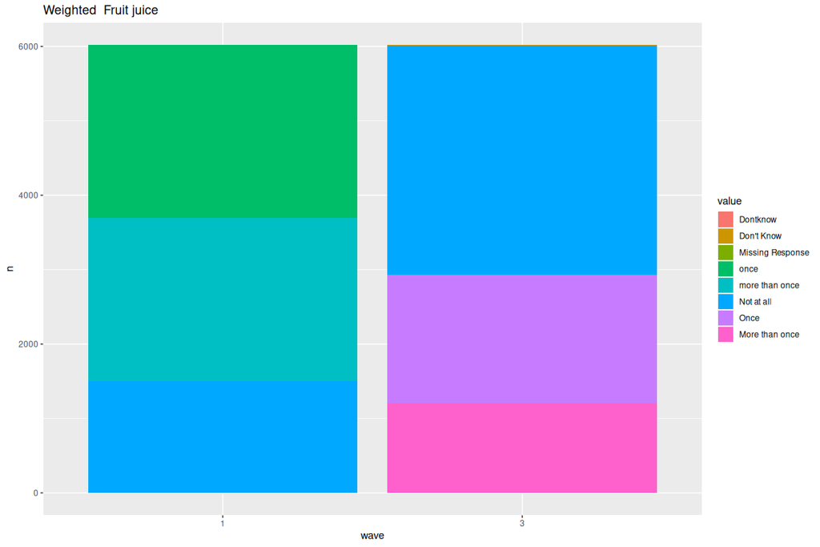

|  | 1 | 2 | 3 |
| --- | --- | --- | --- |
| Don’t Know | 0 | 0 | 6 |
| Dontknow | 1 | 0 | 0 |
| Missing Response | 0 | 0 | 0 |
| more than once | 2191 | 0 | 0 |
| More than once | 0 | 0 | 1207 |
| Not at all | 1507 | 0 | 3088 |
| once | 2321 | 0 | 0 |
| Once | 0 | 0 | 1719 |

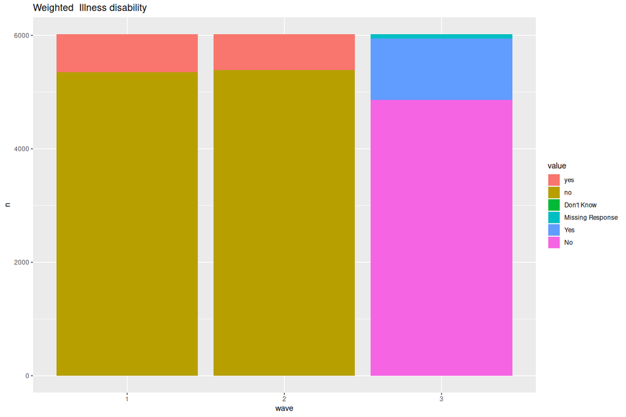

|  | 1 | 2 | 3 |
| --- | --- | --- | --- |
| Don’t Know | 0 | 1 | 0 |
| Missing Response | 0 | 1 | 74 |
| no | 5355 | 5385 | 0 |
| No | 0 | 0 | 4860 |
| yes | 665 | 633 | 0 |
| Yes | 0 | 0 | 1086 |

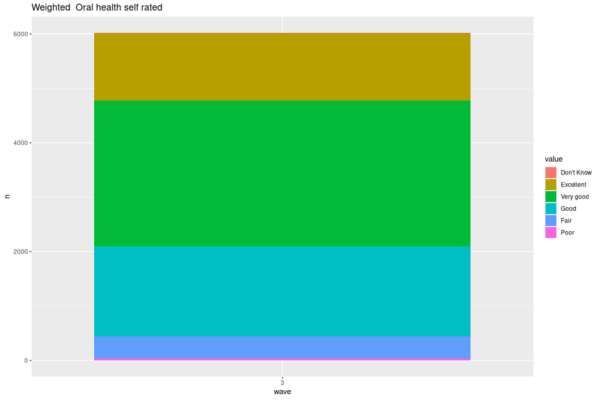

|  | 1 | 2 | 3 |
| --- | --- | --- | --- |
| Don’t Know | 0 | 0 | 6 |
| Excellent | 0 | 0 | 1233 |
| Fair | 0 | 0 | 406 |
| Good | 0 | 0 | 1658 |
| Poor | 0 | 0 | 36 |
| Very good | 0 | 0 | 2680 |

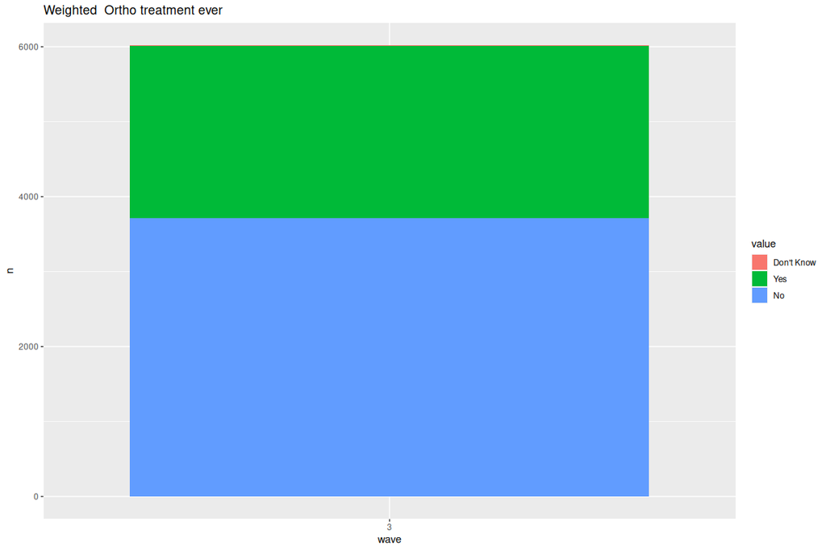

|  | 1 | 2 | 3 |
| --- | --- | --- | --- |
| Don’t Know | 0 | 0 | 9 |
| No | 0 | 0 | 3716 |
| Yes | 0 | 0 | 2295 |

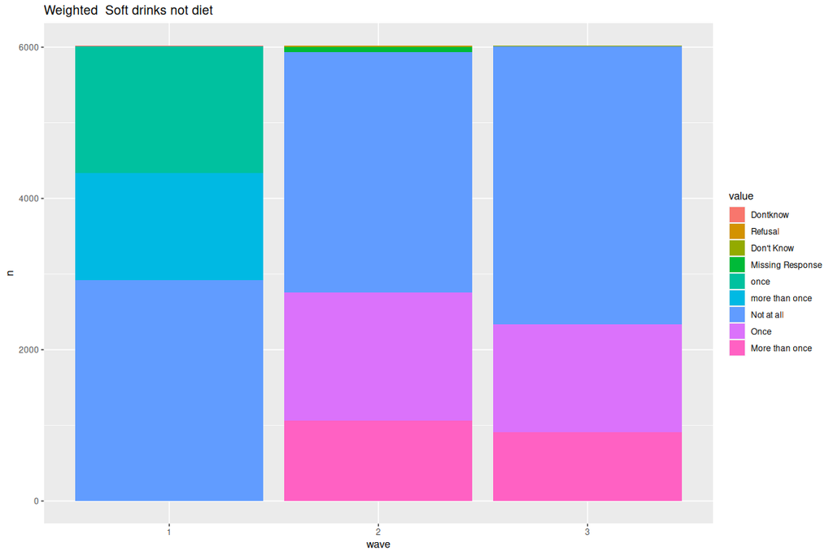

|  | 1 | 2 | 3 |
| --- | --- | --- | --- |
| Don’t Know | 0 | 11 | 6 |
| Dontknow | 4 | 0 | 0 |
| Missing Response | 0 | 67 | 0 |
| more than once | 1419 | 0 | 0 |
| More than once | 0 | 1060 | 907 |
| Not at all | 2921 | 3177 | 3680 |
| once | 1676 | 0 | 0 |
| Once | 0 | 1700 | 1427 |
| Refusal | 0 | 4 | 0 |

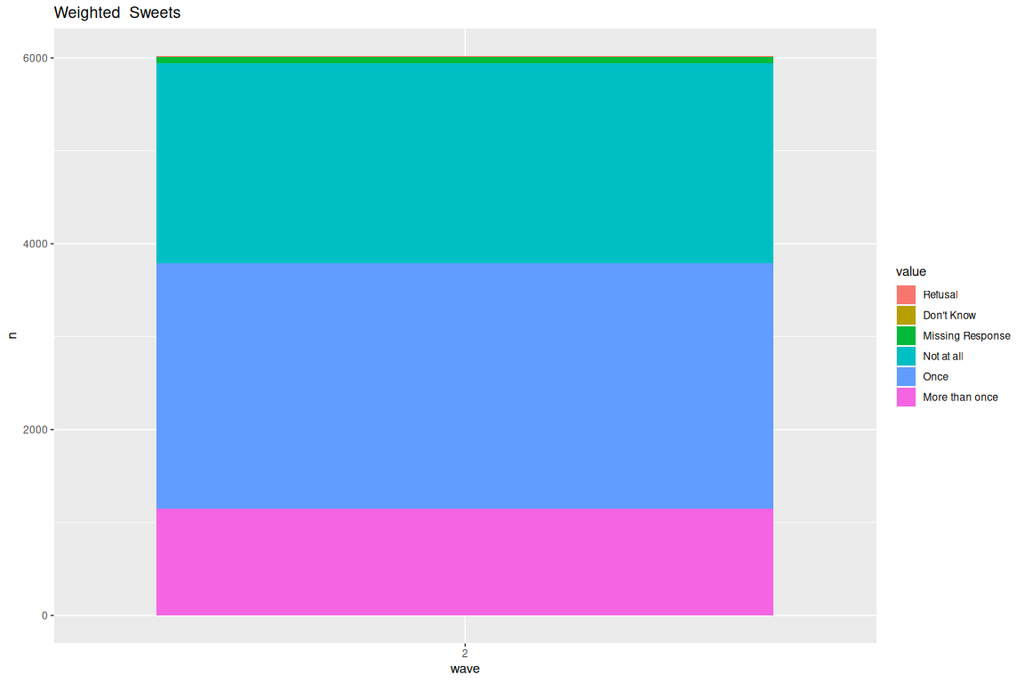

|  | 1 | 2 | 3 |
| --- | --- | --- | --- |
| Don’t Know | 0 | 7 | 0 |
| Missing Response | 0 | 67 | 0 |
| More than once | 0 | 1152 | 0 |
| Not at all | 0 | 2147 | 0 |
| Once | 0 | 2642 | 0 |
| Refusal | 0 | 5 | 0 |

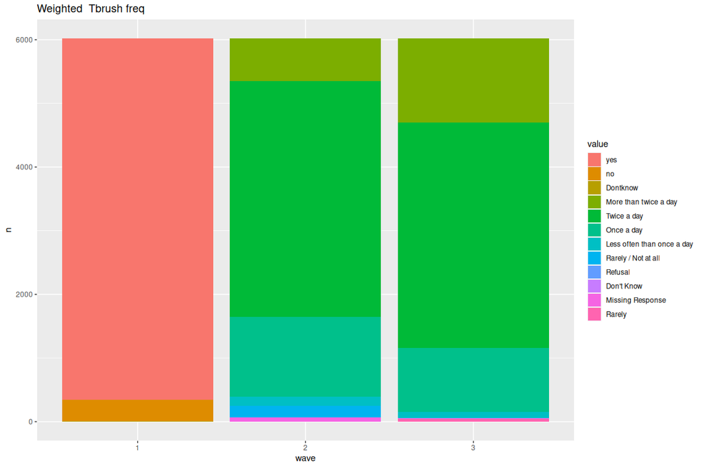

|  | 1 | 2 | 3 |
| --- | --- | --- | --- |
| Don’t Know | 0 | 0 | 6 |
| Dontknow | 6 | 0 | 0 |
| Less often than once a day | 0 | 146 | 100 |
| Missing Response | 0 | 67 | 0 |
| More than twice a day | 0 | 673 | 1319 |
| no | 340 | 0 | 0 |
| Once a day | 0 | 1255 | 1010 |
| Rarely | 0 | 0 | 47 |
| Rarely / Not at all | 0 | 178 | 0 |
| Refusal | 0 | 4 | 0 |
| Twice a day | 0 | 3697 | 3538 |
| yes | 5674 | 0 | 0 |

# 5 Remapping

```
## hash-2.2.6.2 provided by Decision Patterns
```

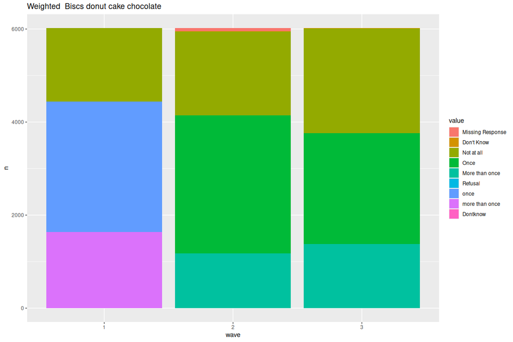

|  | 1 | 2 | 3 |
| --- | --- | --- | --- |
| Don’t Know | 0 | 5 | 6 |
| Dontknow | 2 | 0 | 0 |
| Missing Response | 0 | 67 | 0 |
| more than once | 1638 | 0 | 0 |
| More than once | 0 | 1174 | 1380 |
| Not at all | 1576 | 1807 | 2253 |
| once | 2804 | 0 | 0 |
| Once | 0 | 2962 | 2380 |
| Refusal | 0 | 4 | 0 |

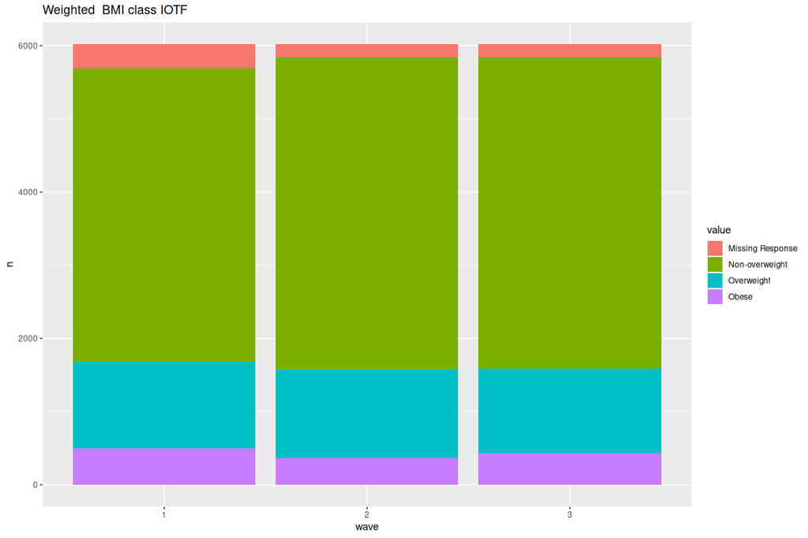

|  | 1 | 2 | 3 |
| --- | --- | --- | --- |
| Missing Response | 330 | 180 | 182 |
| Non-overweight | 4005 | 4258 | 4251 |
| Obese | 502 | 363 | 431 |
| Overweight | 1183 | 1219 | 1157 |

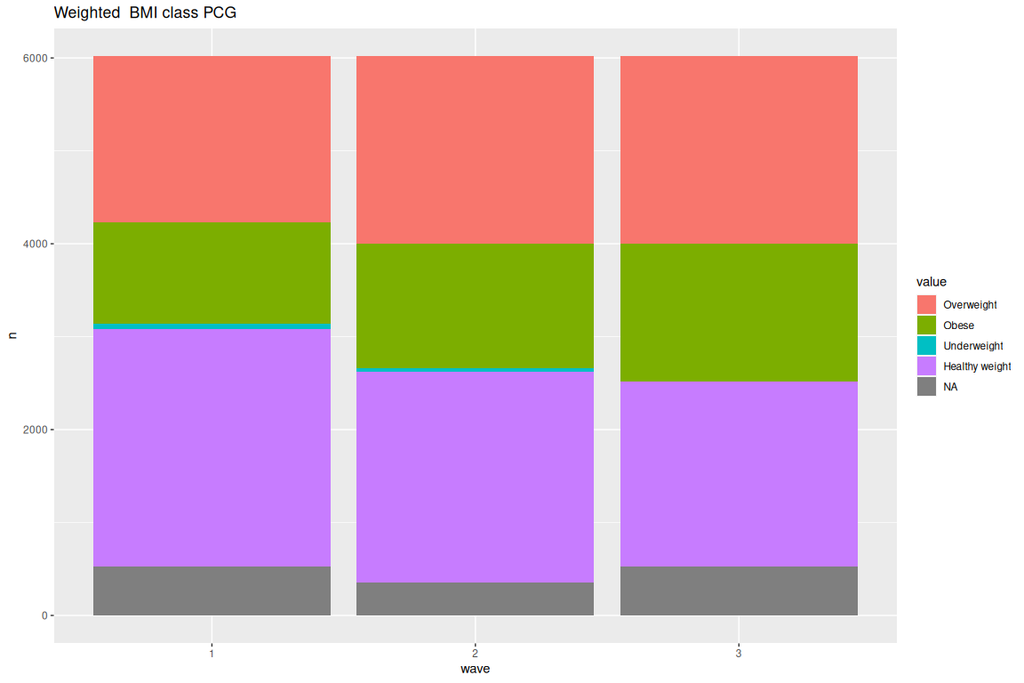

|  | 1 | 2 | 3 |
| --- | --- | --- | --- |
| Healthy weight | 2553 | 2272 | 1993 |
| Obese | 1096 | 1340 | 1477 |
| Overweight | 1787 | 2023 | 2021 |
| Underweight | 54 | 32 | 0 |

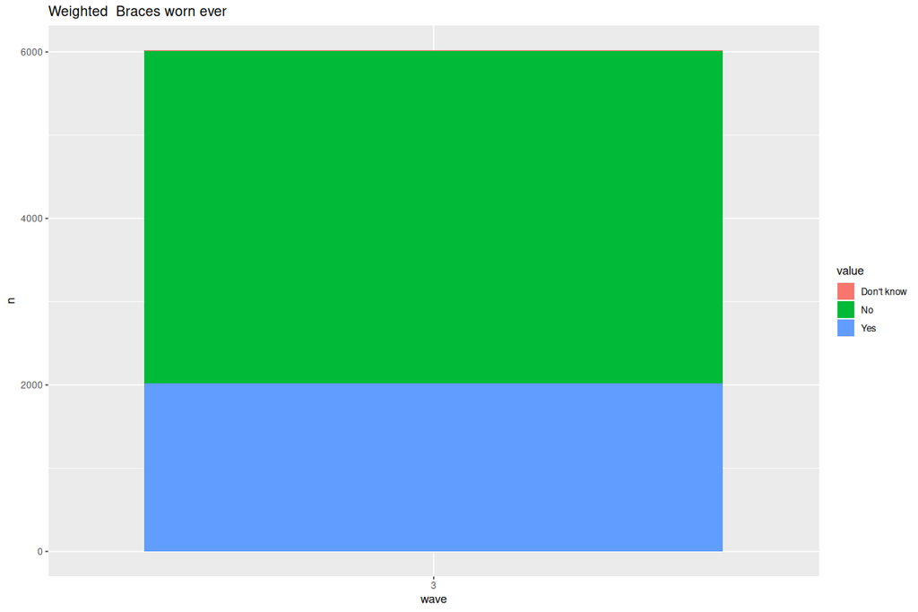

|  | 1 | 2 | 3 |
| --- | --- | --- | --- |
| Don’t know | 0 | 0 | 6 |
| No | 0 | 0 | 3993 |
| Yes | 0 | 0 | 2021 |

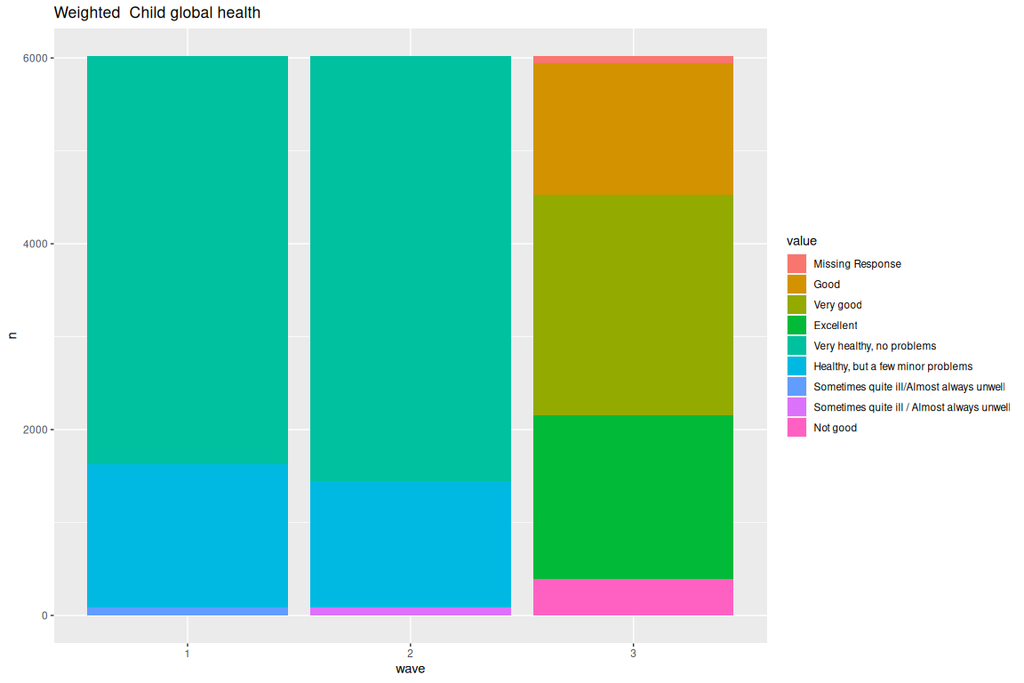

|  | 1 | 2 | 3 |
| --- | --- | --- | --- |
| Excellent | 0 | 0 | 1764 |
| Good | 0 | 0 | 1417 |
| Healthy, but a few minor problems | 1546 | 1361 | 0 |
| Missing Response | 0 | 1 | 74 |
| Not good | 0 | 0 | 394 |
| Sometimes quite ill / Almost always unwell | 0 | 84 | 0 |
| Sometimes quite ill/Almost always unwell | 85 | 0 | 0 |
| Very good | 0 | 0 | 2371 |
| Very healthy, no problems | 4389 | 4575 | 0 |

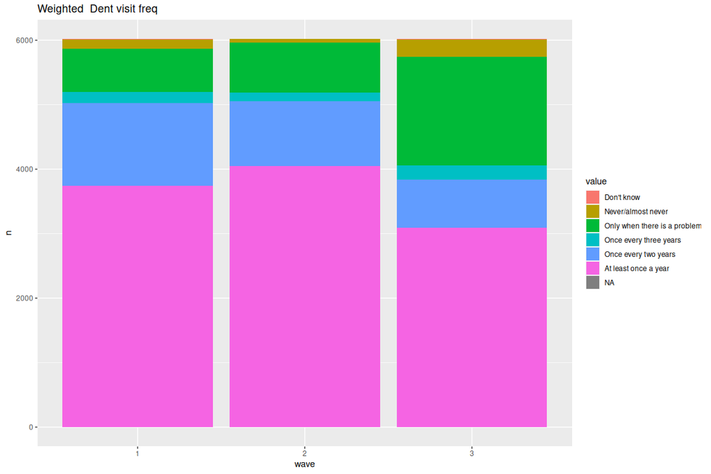

|  | 1 | 2 | 3 |
| --- | --- | --- | --- |
| At least once a year | 3747 | 4049 | 3092 |
| Don’t know | 8 | 2 | 7 |
| Never/almost never | 144 | 53 | 270 |
| Once every three years | 167 | 140 | 215 |
| Once every two years | 1281 | 1002 | 749 |
| Only when there is a problem | 674 | 774 | 1687 |

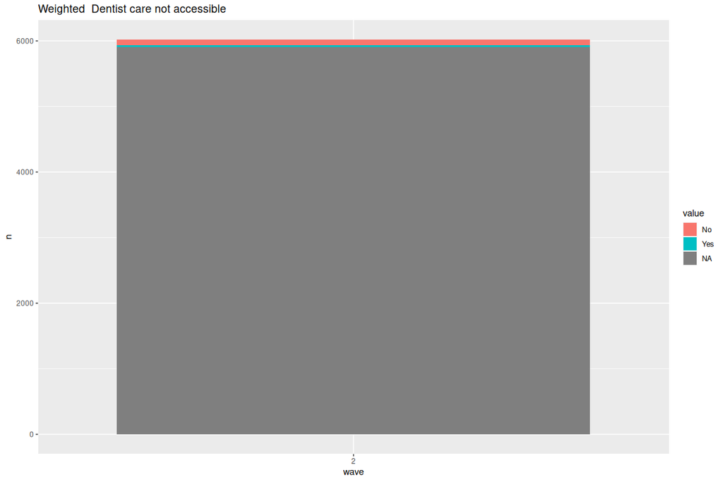

|  | 1 | 2 | 3 |
| --- | --- | --- | --- |
| No | 0 | 84 | 0 |
| Yes | 0 | 26 | 0 |

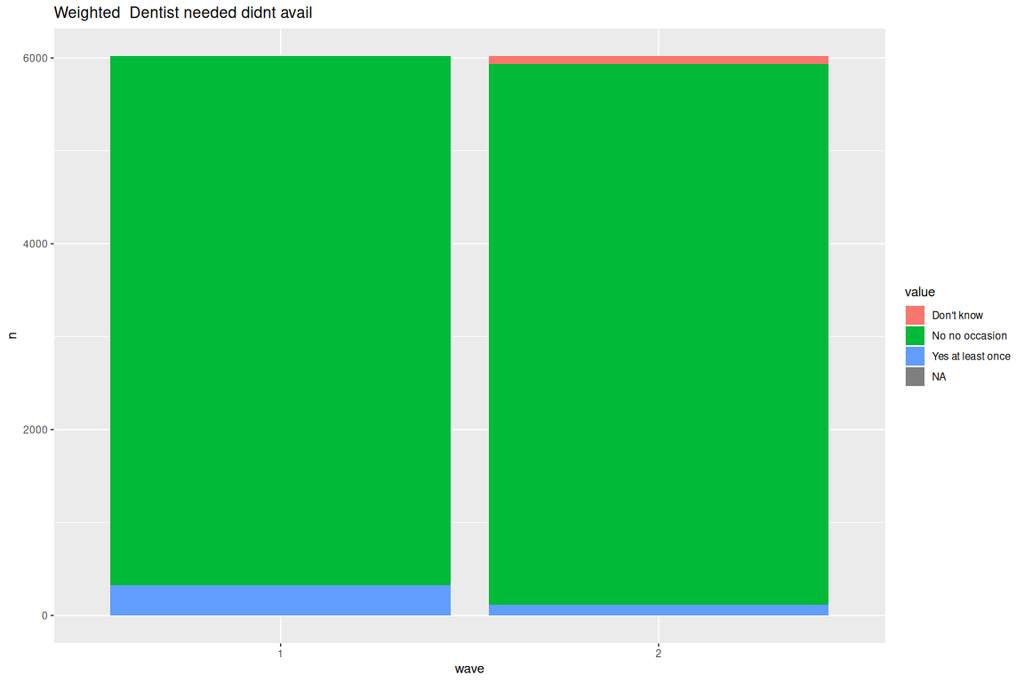

|  | 1 | 2 | 3 |
| --- | --- | --- | --- |
| Don’t know | 0 | 87 | 0 |
| No no occasion | 5694 | 5823 | 0 |
| Yes at least once | 326 | 110 | 0 |

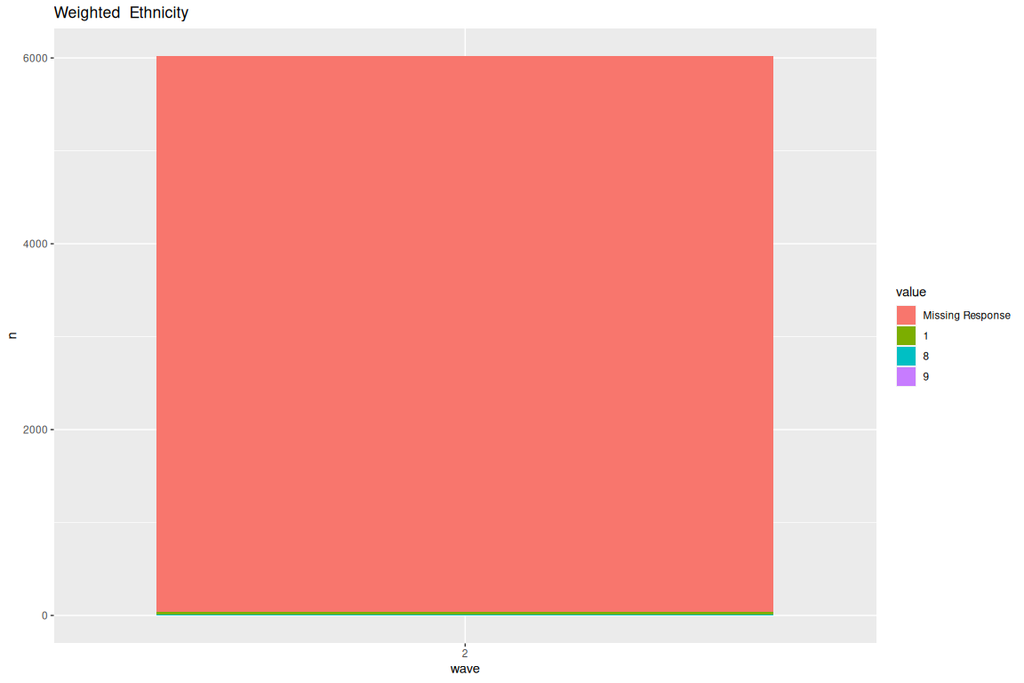

|  | 1 | 2 | 3 |
| --- | --- | --- | --- |
| 1 | 0 | 35 | 0 |
| 8 | 0 | 5 | 0 |
| 9 | 0 | 1 | 0 |
| Missing Response | 0 | 5979 | 0 |

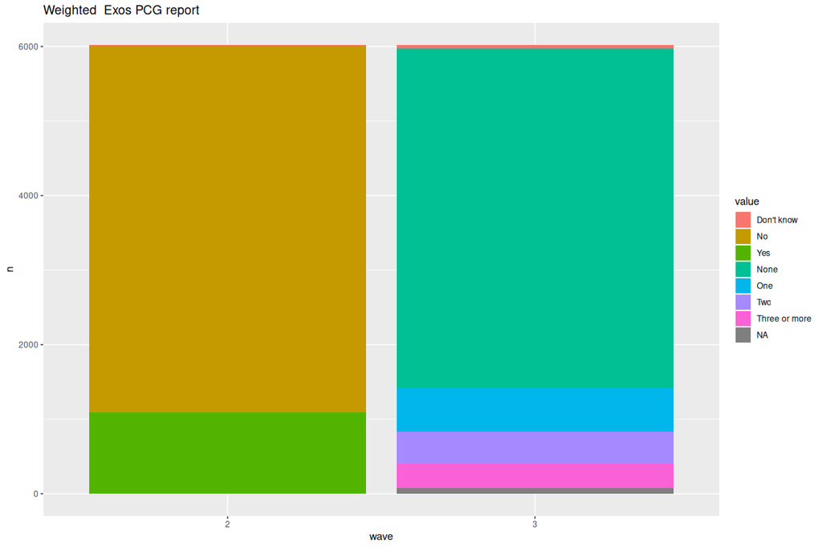

|  | 1 | 2 | 3 |
| --- | --- | --- | --- |
| Don’t know | 0 | 12 | 43 |
| No | 0 | 4913 | 0 |
| None | 0 | 0 | 4559 |
| One | 0 | 0 | 585 |
| Three or more | 0 | 0 | 331 |
| Two | 0 | 0 | 429 |
| Yes | 0 | 1094 | 0 |

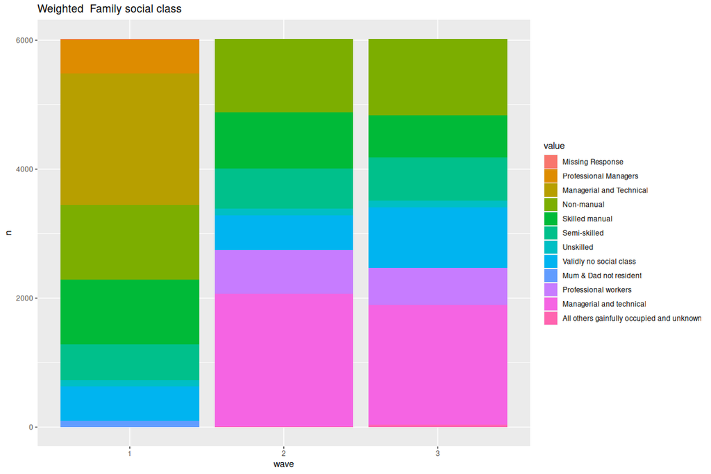

|  | 1 | 2 | 3 |
| --- | --- | --- | --- |
| All others gainfully occupied and unknown | 0 | 9 | 35 |
| Managerial and technical | 0 | 2055 | 1858 |
| Managerial and Technical | 2043 | 0 | 0 |
| Missing Response | 4 | 0 | 0 |
| Mum & Dad not resident | 94 | 0 | 0 |
| Non-manual | 1150 | 1135 | 1188 |
| Professional Managers | 531 | 0 | 0 |
| Professional workers | 0 | 679 | 578 |
| Semi-skilled | 552 | 624 | 671 |
| Skilled manual | 1009 | 877 | 648 |
| Unskilled | 103 | 99 | 111 |
| Validly no social class | 534 | 542 | 932 |

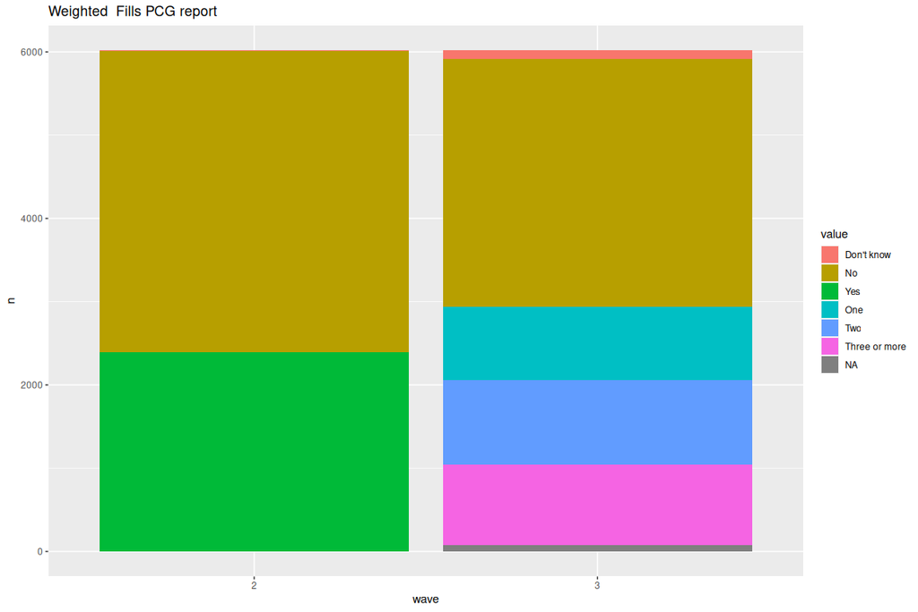

|  | 1 | 2 | 3 |
| --- | --- | --- | --- |
| Don’t know | 0 | 11 | 106 |
| No | 0 | 3616 | 2974 |
| One | 0 | 0 | 879 |
| Three or more | 0 | 0 | 967 |
| Two | 0 | 0 | 1020 |
| Yes | 0 | 2393 | 0 |

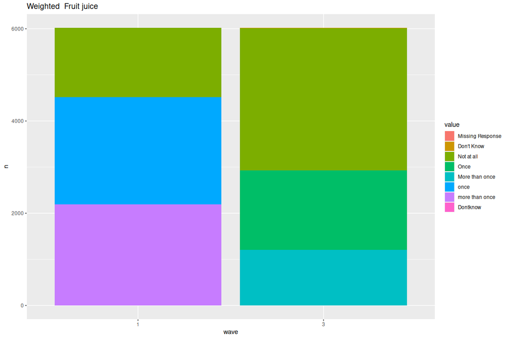

|  | 1 | 2 | 3 |
| --- | --- | --- | --- |
| Don’t Know | 0 | 0 | 6 |
| Dontknow | 1 | 0 | 0 |
| Missing Response | 0 | 0 | 0 |
| more than once | 2191 | 0 | 0 |
| More than once | 0 | 0 | 1207 |
| Not at all | 1507 | 0 | 3088 |
| once | 2321 | 0 | 0 |
| Once | 0 | 0 | 1719 |

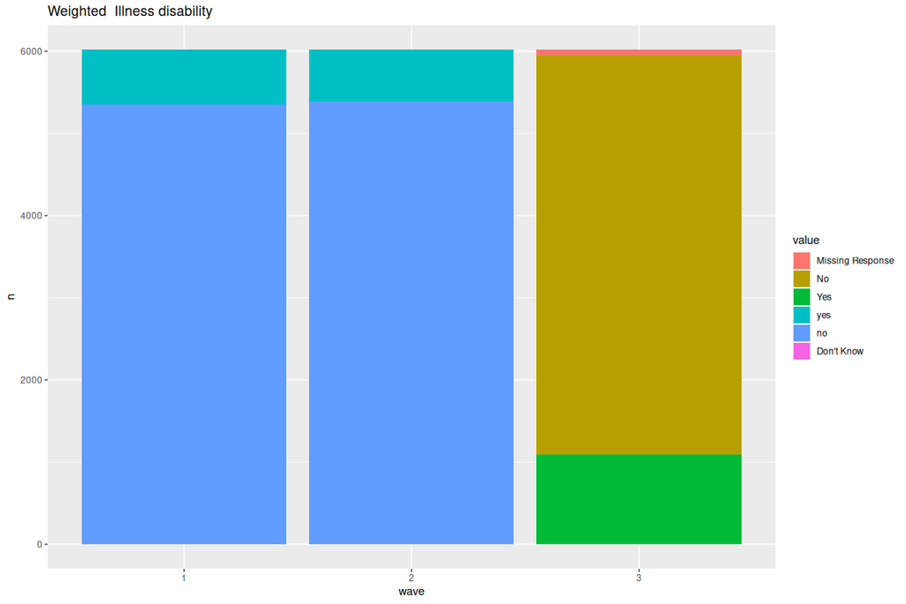

|  | 1 | 2 | 3 |
| --- | --- | --- | --- |
| Don’t Know | 0 | 1 | 0 |
| Missing Response | 0 | 1 | 74 |
| no | 5355 | 5385 | 0 |
| No | 0 | 0 | 4860 |
| yes | 665 | 633 | 0 |
| Yes | 0 | 0 | 1086 |

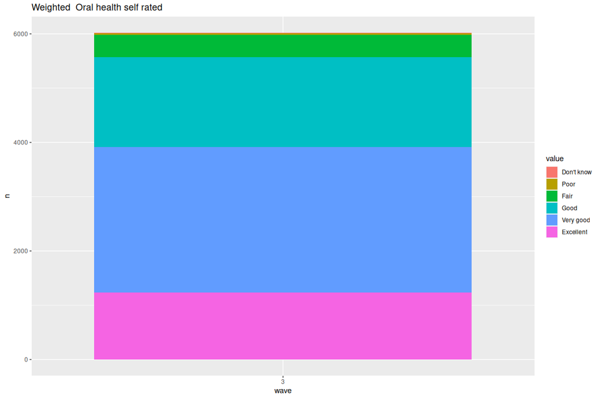

|  | 1 | 2 | 3 |
| --- | --- | --- | --- |
| Don’t know | 0 | 0 | 6 |
| Excellent | 0 | 0 | 1233 |
| Fair | 0 | 0 | 406 |
| Good | 0 | 0 | 1658 |
| Poor | 0 | 0 | 36 |
| Very good | 0 | 0 | 2680 |

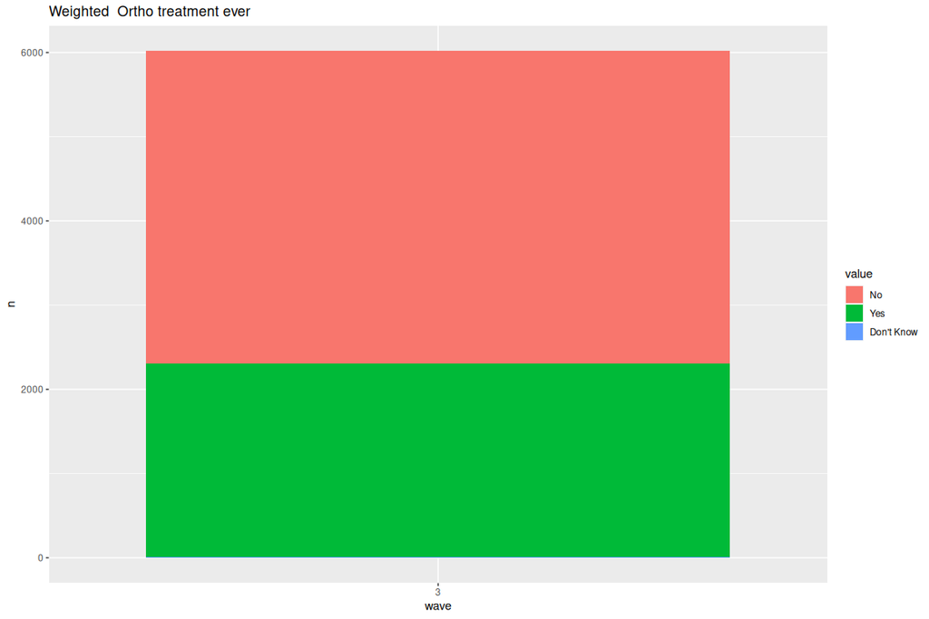

|  | 1 | 2 | 3 |
| --- | --- | --- | --- |
| Don’t Know | 0 | 0 | 9 |
| No | 0 | 0 | 3716 |
| Yes | 0 | 0 | 2295 |

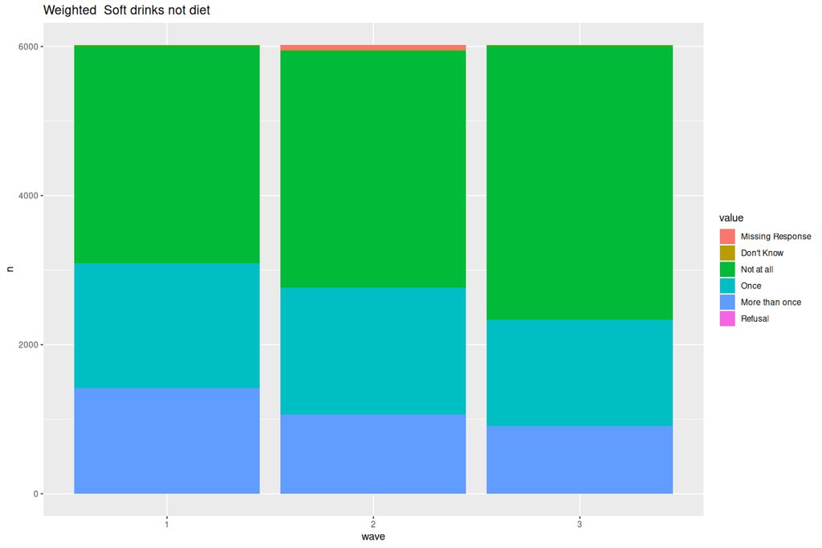

|  | 1 | 2 | 3 |
| --- | --- | --- | --- |
| Don’t Know | 4 | 11 | 6 |
| Missing Response | 0 | 67 | 0 |
| More than once | 1419 | 1060 | 907 |
| Not at all | 2921 | 3177 | 3680 |
| Once | 1676 | 1700 | 1427 |
| Refusal | 0 | 4 | 0 |

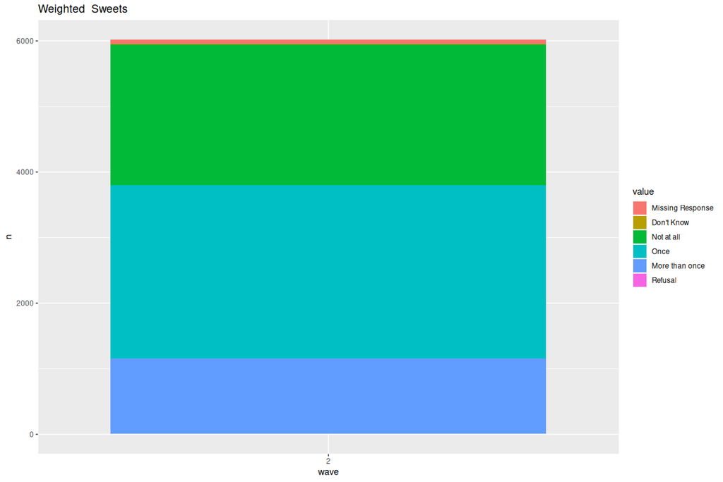

|  | 1 | 2 | 3 |
| --- | --- | --- | --- |
| Don’t Know | 0 | 7 | 0 |
| Missing Response | 0 | 67 | 0 |
| More than once | 0 | 1152 | 0 |
| Not at all | 0 | 2147 | 0 |
| Once | 0 | 2642 | 0 |
| Refusal | 0 | 5 | 0 |

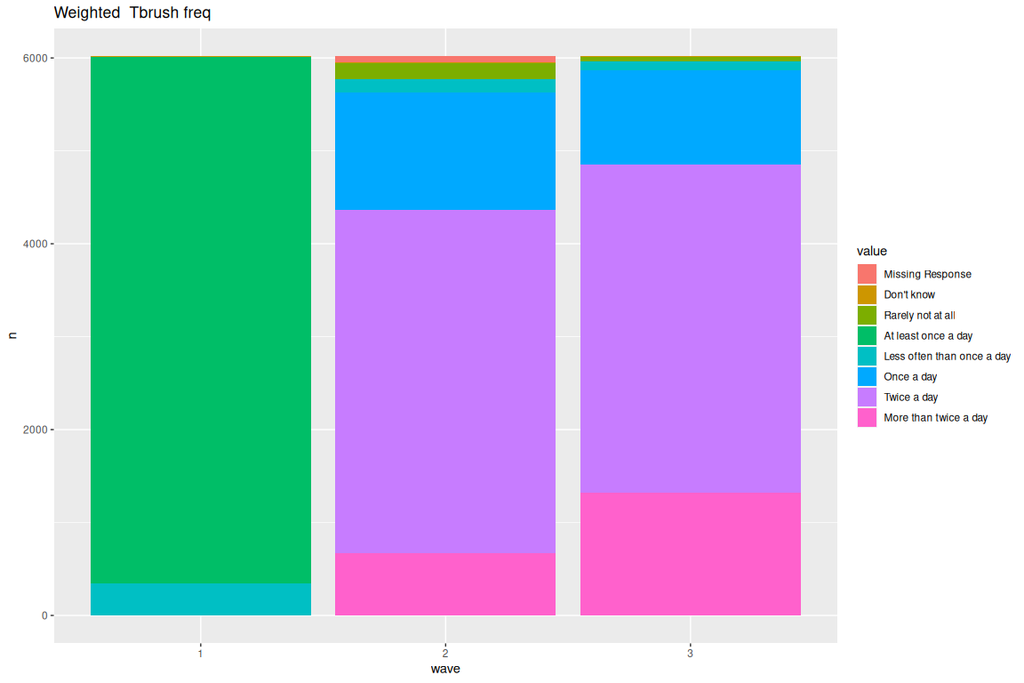

|  | 1 | 2 | 3 |
| --- | --- | --- | --- |
| At least once a day | 5674 | 0 | 0 |
| Don’t know | 6 | 4 | 6 |
| Less often than once a day | 340 | 146 | 100 |
| Missing Response | 0 | 67 | 0 |
| More than twice a day | 0 | 673 | 1319 |
| Once a day | 0 | 1255 | 1010 |
| Rarely not at all | 0 | 178 | 47 |
| Twice a day | 0 | 3697 | 3538 |

| id | Gender_yp | variable | value | wave |
| --- | --- | --- | --- | --- |
| 1 | Male | Tbrush_freq_9 | At least once a day | 9 |
| 2 | Male | Tbrush_freq_9 | At least once a day | 9 |
| 3 | Male | Tbrush_freq_9 | At least once a day | 9 |
| 4 | Male | Tbrush_freq_9 | At least once a day | 9 |
| 5 | Male | Tbrush_freq_9 | At least once a day | 9 |
| 6 | Male | Tbrush_freq_9 | At least once a day | 9 |
| 7 | Male | Tbrush_freq_9 | At least once a day | 9 |
| 8 | Male | Tbrush_freq_9 | At least once a day | 9 |
| 9 | Male | Tbrush_freq_9 | At least once a day | 9 |
| 10 | Male | Tbrush_freq_9 | Less often than once a day | 9 |

| gender | variable | value | wave | sociodem_famsocial | n |
| --- | --- | --- | --- | --- | --- |
| Male | Tbrush_freq_9 | At least once a day | 9 | Managerial and Technical | 1164 |
| Male | Tbrush_freq_9 | At least once a day | 9 | Missing Response | 1 |
| Male | Tbrush_freq_9 | At least once a day | 9 | Mum & Dad not resident | 8 |
| Male | Tbrush_freq_9 | At least once a day | 9 | Non-manual | 540 |
| Male | Tbrush_freq_9 | At least once a day | 9 | Professional Managers | 474 |
| Male | Tbrush_freq_9 | At least once a day | 9 | Semi-skilled | 159 |
| Male | Tbrush_freq_9 | At least once a day | 9 | Skilled manual | 337 |
| Male | Tbrush_freq_9 | At least once a day | 9 | Unskilled | 28 |
| Male | Tbrush_freq_9 | At least once a day | 9 | Validly no social class | 93 |
| Male | Tbrush_freq_9 | Don’t know | 9 | Managerial and Technical | 3 |

| wave | sociodem_famsocial | variable | value | gender | n | total | ratio |
| --- | --- | --- | --- | --- | --- | --- | --- |
| 9 | Managerial and Technical | Tbrush_freq_9 | At least once a day | Male | 1164 | 6039 | 0.1927471 |
| 9 | Missing Response | Tbrush_freq_9 | At least once a day | Male | 1 | 6039 | 0.0001656 |
| 9 | Mum & Dad not resident | Tbrush_freq_9 | At least once a day | Male | 8 | 6039 | 0.0013247 |
| 9 | Non-manual | Tbrush_freq_9 | At least once a day | Male | 540 | 6039 | 0.0894188 |
| 9 | Professional Managers | Tbrush_freq_9 | At least once a day | Male | 474 | 6039 | 0.0784898 |
| 9 | Semi-skilled | Tbrush_freq_9 | At least once a day | Male | 159 | 6039 | 0.0263289 |
| 9 | Skilled manual | Tbrush_freq_9 | At least once a day | Male | 337 | 6039 | 0.0558039 |
| 9 | Unskilled | Tbrush_freq_9 | At least once a day | Male | 28 | 6039 | 0.0046365 |
| 9 | Validly no social class | Tbrush_freq_9 | At least once a day | Male | 93 | 6039 | 0.0153999 |
| 9 | Managerial and Technical | Tbrush_freq_9 | Don’t know | Male | 3 | 6039 | 0.0004968 |